# Лабораторная работа №2

Основные модели: SIR и Лотки-Вольтерры

Назармамадов Умед Джамшедович

1032225205@rudn.ru

Российский университет дружбы народов

# Цель работы

Целью данной лабораторной работы является изучение и реализация двух классических математических моделей: модели распространения инфекции SIR и модели динамики популяций хищник-жертва Лотки-Вольтерры.

# Задание

1. Реализовать модель SIR для описания распространения инфекционного заболевания.
2. Реализовать модель Лотки-Вольтерры для описания динамики хищник-жертва.
3. Провести численное решение систем дифференциальных уравнений.
4. Построить графики динамики популяций.
5. Оформить результаты в виде литературного программирования.

# Теоретическое введение

Модель SIR делит популяцию на три группы: восприимчивые (S), заражённые (I) и выздоровевшие (R). Динамика описывается системой уравнений где бета — коэффициент заражения, гамма — коэффициент выздоровления. Ключевой параметр R0 = бета/гамма показывает среднее число людей которых заражает один больной.

Модель Лотки-Вольтерры описывает взаимодействие хищников и жертв. При росте жертв размножаются хищники, затем из-за нехватки пищи популяция хищников сокращается и цикл повторяется.

# Выполнение лабораторной работы

## Модель SIR

Модель SIR реализована в файле scripts/01_sir_model.jl с использованием библиотеки DifferentialEquations.jl. Система дифференциальных уравнений решается методом Tsit5().

Параметры модели: - Общая численность популяции: N = 1000 - Начальное число заражённых: I0 = 1 - Начальное число восприимчивых: S0 = 999 - Коэффициент заражения: β = 0.3 - Коэффициент выздоровления: γ = 0.1 - Временной интервал: t = [0, 160] дней

Базовое репродуктивное число R0 = β/γ = 3.0, что означает что один больной в среднем заражает троих. Это говорит об активном распространении инфекции в популяции.

В ходе моделирования наблюдается следующая динамика: в начале почти все находятся в группе S. Затем число заражённых I начинает быстро расти. Примерно на 30-й день достигается пик эпидемии. После пика число заражённых убывает, так как всё больше людей переходит в группу R. К концу моделирования эпидемия затухает — часть популяции так и не заразилась.

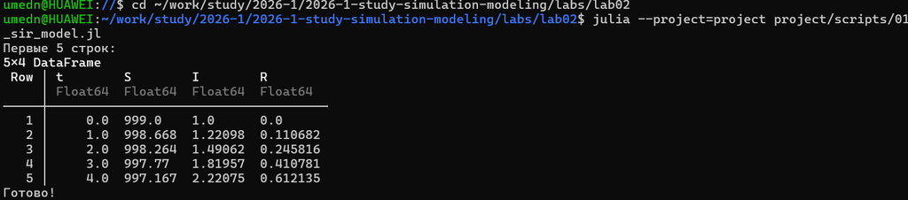

Рисунок 1: Модель SIR

## Модель Лотки-Вольтерры

Модель реализована в файле scripts/02_lotka_volterra.jl. Система также решается методом Tsit5() из библиотеки DifferentialEquations.jl.

Параметры модели: - Начальная численность жертв: x0 = 40 - Начальная численность хищников: y0 = 9 - Скорость роста жертв: α = 0.1 - Скорость выедания жертв хищниками: β = 0.02 - Скорость гибели хищников: γ = 0.4 - Эффективность питания хищников: δ = 0.01 - Временной интервал: t = [0, 200]

[figure not shown]

Рисунок 2: Модель Лотки-Вольтерры

## Генерация производных форматов

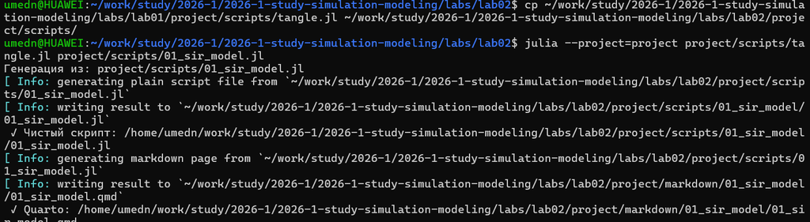

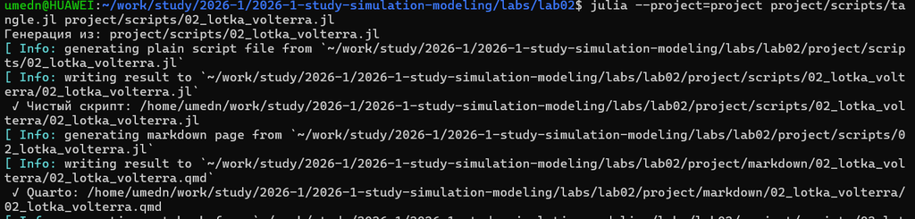

# Выводы

В ходе работы успешно реализованы модели SIR и Лотки-Вольтерры. Модель SIR подтвердила теоретические предсказания о динамике эпидемии. Модель Лотки-Вольтерры продемонстрировала характерные колебания хищников и жертв. Результаты оформлены в виде литературного программирования.